# Identity Encoding Code 01:

Summary Statistics and Preliminary Visual Inspection

[Grace Smith-Vidaurre](http://smith-vidaurre.com/)<sup>1-4*</sup> <sup>1</sup>Department of Biology, New Mexico State University <sup>2</sup>Laboratory of Neurogenetics of Language, Rockefeller University <sup>3</sup>Field Research Center, Rockefeller University <sup>4</sup>Department of Biological Sciences, University of Cincinnati *gsvidaurre@gmail.com

12 June, 2023

This code accompanies the following paper in PLOS Computational Biology:

Smith-Vidaurre, G., Perez-Marrufo, V., Hobson, E.A., Salinas-Melgoza, A., and T.F. Wright. 2023. Individual identity information persists in learned calls of introduced parrot populations.

Introduced range calls were taken through a pre-processing workflow similar to previously published native range calls<sup>[1]</sup>. Previously published introduced range calls for 2004 were provided by Susannah Bhurman-Deever<sup>[2]</sup>, and were pre-processed as were all other calls. The package `warbleR`<sup>[3]</sup> was used for pre-processing, making extended selection tables, and downstream analyses.

Below are summary statistics of the combined native and introduced range call datasets across the individual and site social scales. See the methods and appendix of the associated publication for more information. Check out Github repositories from previous work for related analyses and code:

- gsvidaurre/strong-individual-signatures<sup>[1]</sup>
- gsvidaurre/simpler-signatures-post-invasion<sup>[4]</sup>

Please cite both the associated papers and code (see DOIs on GitHub) if the code or analyses in these repositories are useful for your own research.

```r
rm(list = ls())

X <- c("warbleR", "pbapply", "Rraven", "tidyverse", "ggplot2", "data.table", "lubridate", "pracma", "knitr", "ggsn", "maptools", "png", "rgdal", "rgeos", "sp")
invisible(lapply(X, library, character.only = TRUE))

# Suppress summarise warnings from dplyr
options(dplyr.summarise.inform = FALSE)

path <- "/media/gsvidaurre/MYIOPSITTA/R/VocalLearning_PostDisruption/Data"
gpath <- "/media/gsvidaurre/MYIOPSITTA/R/VocalLearning_PostDisruption/Graphics"

seed <- 401

cores <- parallel::detectCores() - 2
```

Read in the extended selection table (EST) that contains metadata and wave objects for pre-processed native and introduced range calls across the individual and site scales.

```r
nat_int_est <- readRDS(file.path(path, "monk_parakeet_contactCalls_rangeComparison_extSelTable.RDS"))
# glimpse(nat_int_est)
```

The extended selection table in .RDS format, the selection table in .csv format, and the .wav files containing pre-processed calls were made publicly available with the associated article.

Write out the selection table (e.g. the data frame associated with the extended selection table) for sharing, as well as the .wav files associated with the extended selection table. Each .wav file corresponds to a cut of the original recording that contains the selected call and a small margin around the given call (with the exception of 2004 calls, which were obtained for this study as cuts of original recordings). The reason for writing out the data in this way is that the .RDS file of the extended selection table saved above may not be compatible with later versions of R.

```r
# Write out the selection table as a .csv
write.csv(nat_int_est, file.path("/home/gsvidaurre/Desktop/MANUSCRIPTS/Submitted_InReview/HierarchicalMapping_Introduction/Share_Data/Data", "monk_parakeet_contactCalls_rangeComparison_selectionTable.csv"), row.names = FALSE)

# Write out the .wav files to a directory in which I'm using to compile data for sharing

# Access the wave objects
length(attr(nat_int_est, "wave.objects"))
attr(nat_int_est, "wave.objects")[1]

# Get the .wav objects and their respective filenames in order to write these out as separate .wav files
wavs <- attr(nat_int_est, "wave.objects")
wav_nms <- names(attr(nat_int_est, "wave.objects"))

# x <- 1 testing
tmp_path <- "/home/gsvidaurre/Desktop/MANUSCRIPTS/Submitted_InReview/HierarchicalMapping_Introduction/Share_Data/Data/pre-processed_calls"
invisible(pblapply(1:length(wavs), function(x){
  writeWave(wavs[[x]], filename = file.path(tmp_path, wav_nms[x]), extensible = FALSE)
}))
```

# Filtering out some calls

I dropped individual scale calls that had been added to the site scale (1 call per known repeatedly sampled individual in the final individual scale dataset, suffix “site_scale”).

```r
# 31 calls with the suffix "_site_scale". Not all of these belonged to the individuals in the final individual scale dataset, since some individuals that we repeatedly sampled were dropped due to low sample sizes after pre-processing
nat_int_est %>%
  dplyr::filter(social_scale == "Site") %>%
  dplyr::filter(grepl("_site_scale", sound.files)) %>%
  pull(sound.files) %>%
  length()
```

```
## [1] 31
```

```r
# Get the "_site_scale" calls for the final dataset of known repeatedly sampled individuals
indiv_ids <- nat_int_est %>%
  dplyr::filter(social_scale == "Individual") %>%
  pull(Bird_ID) %>%
  unique()

# 17 total: 8 native and 9 introduced range
indiv_ids
```

```
##  [1] "NAT-RAW"  "NAT-ZW8"  "NAT-UM2"  "NAT-UM3"  "NAT-UM4"  "NAT-UM1"
##  [7] "NAT-AAT"  "NAT-UM5"  "INT-UM1"  "INT-UM5"  "INT-UM6"  "INT-UM7"
## [13] "INT-UM9"  "INT-UM10" "INT-UM16" "INT-UM17" "INT-UM19"
```

```r
# INT-UM1, INT-UM6, and INT-UM19 were each the sole bird sampled at sites BART, ASCA, and CAME, respectively. These sites were not included at the site scale, so these individuals did not have any "_site_scale" calls
# This leaves 14 calls to drop, each representing a call for a different repeatedly sampled individual included in the site scale dataset
drop_is_calls <- nat_int_est %>%
  dplyr::filter(social_scale == "Site") %>%
  dplyr::filter(grepl("_site_scale", sound.files)) %>%
  dplyr::filter(Bird_ID %in% indiv_ids) %>%
  pull(sound.files)

length(drop_is_calls)
```

```
## [1] 14
```

```r
# Checking, looks good
# nat_int_est %>%
#   as_tibble() %>%
#   dplyr::filter(sound.files %in% drop_is_calls) %>%
#   dplyr::select(sound.files, Bird_ID) %>%
#   kable(align = rep("c", nrow(.)))

# Drop these calls from the extended selection table and continue with analyses
# nat_int_est <- nat_int_est %>%
  # dplyr::filter(!sound.files %in% drop_is_calls)

# Don't use tidyverse since I want to filter both the data frame and the .wav objects in the EST
nat_int_est <- nat_int_est[-grep(paste(paste("^", drop_is_calls, "$", sep = ""), collapse = "|"), nat_int_est$sound.files), ]

# 1582 calls remain out of the original 1596 calls read in above
dim(nat_int_est)
```

```
## [1] 1582   26
```

```r
class(nat_int_est)
```

```
## [1] "extended_selection_table" "data.frame"
```

```r
glimpse(nat_int_est)
```

```
## Rows: 1,582
## Columns: 26
## $ sound.files          <chr> "2017_07_17_EMBR_INDIV-RAW_MZ000199_1.WAV", "2017…
## $ selec                <dbl> 1, 1, 1, 1, 1, 1, 1, 1, 1, 1, 1, 1, 1, 1, 1, 1, 1…
## $ start                <dbl> 0.05, 0.05, 0.05, 0.05, 0.05, 0.05, 0.05, 0.05, 0…
## $ end                  <dbl> 0.2646363, 0.2310324, 0.2509257, 0.2378781, 0.220…
## $ date                 <date> 2017-07-17, 2017-07-17, 2017-07-17, 2017-07-17, …
## $ range                <chr> "Native", "Native", "Native", "Native", "Native",…
## $ social_scale         <chr> "Individual", "Individual", "Individual", "Indivi…
## $ site                 <chr> "EMBR", "EMBR", "EMBR", "EMBR", "EMBR", "EMBR", "…
## $ Bird_ID              <chr> "NAT-RAW", "NAT-RAW", "NAT-RAW", "NAT-RAW", "NAT-…
## $ lat                  <dbl> -34.44437, -34.44437, -34.44437, -34.44437, -34.4…
## $ lon                  <dbl> -57.72845, -57.72845, -57.72845, -57.72845, -57.7…
## $ Visual_quality_score <fct> H, M, H, H, M, M, M, H, M, H, H, H, M, M, H, H, H…
## $ Overlapping_signal   <fct> N, N, N, N, N, N, N, N, N, N, N, N, N, N, N, N, N…
## $ Truncated            <chr> "N", "N", "N", "N", "N", "N", "N", "N", "N", "N",…
## $ tailored             <fct> y, y, y, y, y, y, y, y, y, y, y, y, y, y, y, y, y…
## $ prev_SNR             <dbl> 20.10350, 14.90409, 18.55063, 18.49727, 18.74672,…
## $ SNR_margin_works     <chr> "Y", "Y", "Y", "Y", "Y", "Y", "Y", "Y", "Y", "Y",…
## $ SNR_before_only      <chr> NA, NA, NA, NA, NA, NA, NA, NA, NA, NA, NA, NA, N…
## $ old.sound.file.name  <chr> "2017_07_17_EMBR_INDIV-RAW_MZ000199_1.WAV", "2017…
## $ SNR                  <dbl> 23.45415, 22.14815, 15.36660, 19.25200, 21.86770,…
## $ region               <chr> "West", "West", "West", "West", "West", "West", "…
## $ country              <chr> "Uruguay", "Uruguay", "Uruguay", "Uruguay", "Urug…
## $ site_year            <chr> "EMBR_2017", "EMBR_2017", "EMBR_2017", "EMBR_2017…
## $ year                 <chr> "2017", "2017", "2017", "2017", "2017", "2017", "…
## $ dept_state           <chr> "Colonia", "Colonia", "Colonia", "Colonia", "Colo…
## $ introduced_city      <chr> NA, NA, NA, NA, NA, NA, NA, NA, NA, NA, NA, NA, N…
```

# Individual scale

The total number of calls from repeatedly sampled individuals between ranges and by range.

```r
nat_int_est %>%
  as_tibble() %>%
  filter(social_scale == "Individual") %>%
  dplyr::count() %>%
  # Center all columns of the resulting table
  kable(align = rep("c", ncol(.)))
```

| n |
| --- |
| 229 |

```r
nat_int_est %>%
  as_tibble() %>%
  filter(social_scale == "Individual") %>%
  group_by(range) %>%
  dplyr::count() %>%
  kable(align = rep("c", ncol(.)))
```

| range | n |
| --- | --- |
| Introduced | 132 |
| Native | 97 |

The number of known repeatedly sampled individuals across ranges.

```r
nat_int_est %>%
  as_tibble() %>%
  filter(social_scale == "Individual") %>%
  group_by(range) %>%
  dplyr::summarise(count = n_distinct(Bird_ID)) %>%
  kable(align = rep("c", ncol(.)))
```

| range | count |
| --- | --- |
| Introduced | 9 |
| Native | 8 |

The number of sites at which we sampled known repeatedly sampled individuals across ranges.

```r
nat_int_est %>%
  as_tibble() %>%
  filter(social_scale == "Individual") %>%
  group_by(range) %>%
  dplyr::summarise(count = n_distinct(site)) %>%
  kable(align = rep("c", ncol(.)))
```

| range | count |
| --- | --- |
| Introduced | 7 |
| Native | 3 |

The number of calls per known repeatedly sampled individual across ranges, and recording dates.

```r
nat_int_est %>%
  as_tibble() %>%
  filter(social_scale == "Individual") %>%
  group_by(range, Bird_ID, lat, lon, site, dept_state) %>%
  dplyr::count() %>%
  arrange(range, site) %>%
  inner_join(
    nat_int_est %>%
      as_tibble() %>%
      filter(social_scale == "Individual") %>%
      group_by(range, Bird_ID) %>%
      distinct(date),
    by = c("range", "Bird_ID")
  ) %>%
  ungroup() %>%
  dplyr::mutate(
    lat = round(lat, 3),
    lon = round(lon, 3)
  ) %>%
  dplyr::select(Bird_ID, site, dept_state, lat, lon, n, date) %>%
  kable(align = rep("c", ncol(.)))
```

| Bird_ID | site | dept_state | lat | lon | n | date |
| --- | --- | --- | --- | --- | --- | --- |
| INT-UM6 | ASCA | Texas | 31.754 | -106.405 | 25 | 2019-03-10 |
| INT-UM1 | BART | Texas | 30.305 | -97.695 | 23 | 2011-02-15 |
| INT-UM19 | CAME | Louisiana | 30.022 | -90.065 | 12 | 2004-03-30 |
| INT-UM7 | ELEM | Texas | 30.260 | -97.718 | 28 | 2019-08-06 |
| INT-UM9 | ELEM | Texas | 30.260 | -97.718 | 5 | 2019-08-06 |
| INT-UM10 | INTR | Texas | 30.317 | -97.728 | 6 | 2019-08-08 |
| INT-UM5 | ROBE | Louisiana | 30.021 | -90.069 | 20 | 2011-02-18 |
| INT-UM16 | SOCC | Texas | 30.270 | -97.761 | 8 | 2019-08-09 |
| INT-UM17 | SOCC | Texas | 30.270 | -97.761 | 5 | 2019-08-09 |
| NAT-AAT | 1145 | Colonia | -34.376 | -57.500 | 12 | 2017-07-29 |
| NAT-UM1 | 1145 | Colonia | -34.375 | -57.502 | 25 | 2017-07-28 |
| NAT-UM2 | 1145 | Colonia | -34.375 | -57.502 | 23 | 2017-07-24 |
| NAT-UM3 | 1145 | Colonia | -34.375 | -57.502 | 5 | 2017-07-24 |
| NAT-UM4 | 1145 | Colonia | -34.376 | -57.500 | 13 | 2017-07-26 |
| NAT-UM5 | CHAC | Colonia | -34.413 | -57.843 | 7 | 2017-08-21 |
| NAT-RAW | EMBR | Colonia | -34.444 | -57.728 | 4 | 2017-07-17 |
| NAT-ZW8 | EMBR | Colonia | -34.444 | -57.728 | 8 | 2017-07-21 |

The median and range of the number of calls per known repeatedly sampled individual across ranges.

```r
nat_int_est %>%
  as_tibble() %>%
  filter(social_scale == "Individual") %>%
  group_by(range, Bird_ID) %>%
  dplyr::summarise(num_calls = length(Bird_ID)) %>%
  dplyr::summarise(
    median_calls = round(median(num_calls), 2),
    range_calls = paste(round(range(num_calls), 2), collapse = " - ")
  ) %>%
  kable(align = rep("c", ncol(.)))
```

| range | median_calls | range_calls |
| --- | --- | --- |
| Introduced | 12 | 5 - 28 |
| Native | 10 | 4 - 25 |

```r
nat_int_est %>%
  as_tibble() %>%
  filter(social_scale == "Individual") %>%
  group_by(range) %>%
  filter(!is.na(SNR)) %>%
  dplyr::summarise(
    median_SNR = round(median(SNR), 2),
    range_SNR = paste(round(range(SNR), 2), collapse = " - ")
  ) %>%
  kable(align = rep("c", ncol(.)))
```

| range | median_SNR | range_SNR |
| --- | --- | --- |
| Introduced | 17.23 | 7.5 - 29.11 |
| Native | 16.80 | 9.69 - 26.6 |

# Site scale

Total site scale calls.

```r
nat_int_est %>%
  as_tibble() %>%
  filter(social_scale == "Site") %>%
  dplyr::count() %>%
  # Center all columns of the resulting table
  kable(align = rep("c", ncol(.)))
```

| n |
| --- |
| 1353 |

The total number of sites across ranges.

```r
nat_int_est %>%
  as_tibble() %>%
  filter(social_scale == "Site") %>%
  dplyr::summarise(count = n_distinct(site_year))
```

```
## # A tibble: 1 × 1
##   count
##   <int>
## 1    63
```

The number of site-years across ranges (e.g. unique sites).

```r
nat_int_est %>%
  as_tibble() %>%
  filter(social_scale == "Site") %>%
  group_by(range) %>%
  dplyr::summarise(count = n_distinct(site_year)) %>%
  kable(align = rep("c", ncol(.)))
```

| range | count |
| --- | --- |
| Introduced | 26 |
| Native | 37 |

The number of sites across ranges and years.

```r
nat_int_est %>%
  as_tibble() %>%
  filter(social_scale == "Site") %>%
  group_by(range, year) %>%
  dplyr::summarise(count = n_distinct(site_year)) %>%
  kable(align = rep("c", ncol(.)))
```

| range | year | count |
| --- | --- | --- |
| Introduced | 2004 | 11 |
| Introduced | 2011 | 8 |
| Introduced | 2018 | 1 |
| Introduced | 2019 | 6 |
| Native | 2017 | 37 |

The total number of calls per site-year across ranges.

```r
nat_int_est %>%
  as_tibble() %>%
  filter(social_scale == "Site") %>%
  group_by(range) %>%
  dplyr::summarise(num_calls = length(range)) %>%
  kable(align = rep("c", ncol(.)))
```

| range | num_calls |
| --- | --- |
| Introduced | 751 |
| Native | 602 |

The median and range of the number of calls per site-year.

```r
nat_int_est %>%
  as_tibble() %>%
  filter(social_scale == "Site") %>%
  group_by(range, site_year) %>%
  dplyr::summarise(num_calls = length(site_year)) %>%
  dplyr::summarise(
    median_calls = round(median(num_calls), 2),
    range_calls = paste(round(range(num_calls), 2), collapse = " - ")
  ) %>%
  kable(align = rep("c", ncol(.)))
```

| range | median_calls | range_calls |
| --- | --- | --- |
| Introduced | 15.5 | 5 - 91 |
| Native | 15.0 | 5 - 53 |

The median and range of SNR of site-years across ranges by range.

```r
nat_int_est %>%
  as_tibble() %>%
  filter(social_scale == "Site") %>%
  group_by(range) %>%
  filter(!is.na(SNR)) %>%
  dplyr::summarise(
    median_SNR = round(median(SNR), 2),
    range_SNR = paste(round(range(SNR), 2), collapse = " - ")
  ) %>%
  kable(align = rep("c", ncol(.)))
```

| range | median_SNR | range_SNR |
| --- | --- | --- |
| Introduced | 13.43 | 7.02 - 33.96 |
| Native | 18.77 | 7.98 - 37.19 |

The number of calls, sampling dates and geographic coordinates per site-year across ranges.

```r
nat_int_est %>%
  as_tibble() %>%
  filter(social_scale == "Site") %>%
  group_by(range, site, year, dept_state, introduced_city, lat, lon) %>%
  distinct(date) %>%
  arrange(range, site, dept_state, year) %>%
  ungroup() %>%
  inner_join(
    nat_int_est %>%
      as_tibble() %>%
      filter(social_scale == "Site") %>%
      group_by(range, site, date, lat, lon) %>%
      dplyr::summarise(
        n_calls = length(sound.files)
      ),
  by = c("range", "site", "date", "lat", "lon")
  ) %>%
  dplyr::mutate(
    lat = round(lat, 3),
    lon = round(lon, 3)
  ) %>%
  dplyr::select(range, site, dept_state, introduced_city, lat, lon, n_calls, date) %>%
  kable(align = rep("c", ncol(.)))
```

| range | site | dept_state | introduced_city | lat | lon | n_calls | date |
| --- | --- | --- | --- | --- | --- | --- | --- |
| Introduced | AIRP | Texas | Austin | 30.285 | -97.705 | 9 | 2019-08-07 |
| Introduced | AUDU | Connecticut | Milford | 41.176 | -73.102 | 17 | 2004-03-30 |
| Introduced | BALL | Louisiana | New Orleans | 30.013 | -90.132 | 26 | 2004-03-30 |
| Introduced | BAPT | Florida | Miami | 25.688 | -80.338 | 40 | 2004-03-30 |
| Introduced | BUCK | Connecticut | Milford | 41.217 | -73.038 | 60 | 2004-03-30 |
| Introduced | CANA | Louisiana | New Orleans | 29.981 | -90.110 | 13 | 2004-03-30 |
| Introduced | COMM | Texas | Austin | 30.404 | -97.705 | 11 | 2004-03-30 |
| Introduced | ELEM | Texas | Austin | 30.260 | -97.718 | 12 | 2011-02-15 |
| Introduced | ELEM | Texas | Austin | 30.260 | -97.718 | 59 | 2019-08-06 |
| Introduced | FOLS | Louisiana | New Orleans | 30.027 | -90.205 | 10 | 2004-03-30 |
| Introduced | GILB | Arizona | Gilbert | 33.331 | -111.791 | 16 | 2018-04-09 |
| Introduced | INTR | Texas | Austin | 30.316 | -97.719 | 15 | 2011-02-15 |
| Introduced | INTR | Texas | Austin | 30.317 | -97.728 | 81 | 2019-08-08 |
| Introduced | LAKE | Louisiana | New Orleans | 30.029 | -90.077 | 6 | 2011-02-18 |
| Introduced | LAWT | Texas | Dallas | 32.820 | -96.730 | 9 | 2011-02-20 |
| Introduced | MANO | Texas | Austin | 30.299 | -97.686 | 5 | 2019-08-09 |
| Introduced | MART | Texas | Austin | 30.253 | -97.731 | 14 | 2011-02-15 |
| Introduced | MART | Texas | Austin | 30.251 | -97.731 | 50 | 2019-08-10 |
| Introduced | MEAD | Connecticut | Milford | 41.210 | -73.071 | 28 | 2004-03-30 |
| Introduced | ROBE | Louisiana | New Orleans | 30.021 | -90.069 | 23 | 2011-02-18 |
| Introduced | SHAK | Connecticut | Stratford | 41.184 | -73.126 | 50 | 2004-03-30 |
| Introduced | SOCC | Texas | Austin | 30.272 | -97.767 | 77 | 2004-03-30 |
| Introduced | SOCC | Texas | Austin | 30.270 | -97.761 | 91 | 2019-08-09 |
| Introduced | SOFT | Texas | Austin | 30.281 | -97.725 | 14 | 2011-02-15 |
| Introduced | VALL | Texas | Austin | 30.261 | -97.711 | 5 | 2004-03-30 |
| Introduced | VALL | Texas | Austin | 30.261 | -97.711 | 10 | 2011-02-15 |
| Native | 1145 | Colonia | NA | -34.375 | -57.502 | 6 | 2017-07-26 |
| Native | 1145 | Colonia | NA | -34.376 | -57.500 | 6 | 2017-07-26 |
| Native | ARAP | Salto | NA | -30.946 | -57.520 | 12 | 2017-05-07 |
| Native | ARAZ | San Jose | NA | -34.535 | -56.812 | 15 | 2017-11-03 |
| Native | BAGU | Montevideo | NA | -34.848 | -56.384 | 20 | 2017-10-09 |
| Native | BCAR | Montevideo | NA | -34.788 | -56.223 | 13 | 2017-10-20 |
| Native | CEME | Montevideo | NA | -34.913 | -56.187 | 6 | 2017-10-18 |
| Native | CHAC | Colonia | NA | -34.413 | -57.843 | 11 | 2017-08-21 |
| Native | CISN | Maldonado | NA | -34.861 | -55.150 | 28 | 2017-09-13 |
| Native | ECIL | San Jose | NA | -34.361 | -57.060 | 4 | 2017-07-28 |
| Native | ECIL | San Jose | NA | -34.360 | -57.060 | 13 | 2017-07-28 |
| Native | ELTE | Maldonado | NA | -34.889 | -54.863 | 23 | 2017-09-13 |
| Native | EMBR | Colonia | NA | -34.444 | -57.728 | 21 | 2017-07-21 |
| Native | FAGR | Montevideo | NA | -34.838 | -56.219 | 7 | 2017-09-05 |
| Native | GOLF | Montevideo | NA | -34.923 | -56.164 | 22 | 2017-11-20 |
| Native | HIPE | Maldonado | NA | -34.825 | -55.010 | 5 | 2017-09-12 |
| Native | INBR | Canelones | NA | -34.668 | -56.330 | 19 | 2017-09-03 |
| Native | INES-01 | Colonia | NA | -34.349 | -57.727 | 12 | 2017-07-03 |
| Native | INES-03 | Colonia | NA | -34.336 | -57.668 | 15 | 2017-07-11 |
| Native | INES-04 | Colonia | NA | -34.335 | -57.668 | 9 | 2017-07-11 |
| Native | INES-05 | Colonia | NA | -34.340 | -57.690 | 6 | 2017-07-15 |
| Native | INES-06 | Colonia | NA | -34.344 | -57.708 | 6 | 2017-07-13 |
| Native | INES-07 | Colonia | NA | -34.346 | -57.710 | 9 | 2017-07-13 |
| Native | INES-08 | Colonia | NA | -34.345 | -57.733 | 27 | 2017-07-13 |
| Native | KIYU | San Jose | NA | -34.607 | -56.715 | 8 | 2017-11-03 |
| Native | LENA | Colonia | NA | -34.411 | -57.838 | 19 | 2017-10-23 |
| Native | OJOS | Rocha | NA | -33.804 | -53.506 | 23 | 2017-11-16 |
| Native | PAVO | San Jose | NA | -34.442 | -56.967 | 25 | 2017-10-17 |
| Native | PEIX | Montevideo | NA | -34.765 | -56.279 | 19 | 2017-10-06 |
| Native | PFER | Colonia | NA | -34.468 | -57.831 | 34 | 2017-06-19 |
| Native | PFER | Colonia | NA | -34.465 | -57.827 | 19 | 2017-06-21 |
| Native | PIED | Colonia | NA | -34.413 | -57.849 | 21 | 2017-10-25 |
| Native | PLVE | Maldonado | NA | -34.870 | -55.264 | 11 | 2017-05-21 |
| Native | PROO | Canelones | NA | -34.855 | -56.022 | 12 | 2017-09-14 |
| Native | QUEB | Maldonado | NA | -34.834 | -55.260 | 16 | 2017-09-13 |
| Native | RIAC | Colonia | NA | -34.437 | -57.706 | 17 | 2017-06-28 |
| Native | RIAC | Colonia | NA | -34.436 | -57.706 | 8 | 2017-06-28 |
| Native | ROSA | Colonia | NA | -34.338 | -57.336 | 15 | 2017-07-27 |
| Native | SAUC | Maldonado | NA | -34.857 | -55.041 | 6 | 2017-09-12 |
| Native | SEMI | Colonia | NA | -34.326 | -57.680 | 11 | 2017-07-25 |
| Native | VALI | Rocha | NA | -34.334 | -53.803 | 23 | 2017-11-16 |

# Preliminary visual inspection

Call catalogs or lexicons were made at the individual and site social scales across ranges. These contained a subsample of calls per social scale for preliminary visual inspection.

Randomly sample 3 calls per known repeatedly sampled individual across ranges.

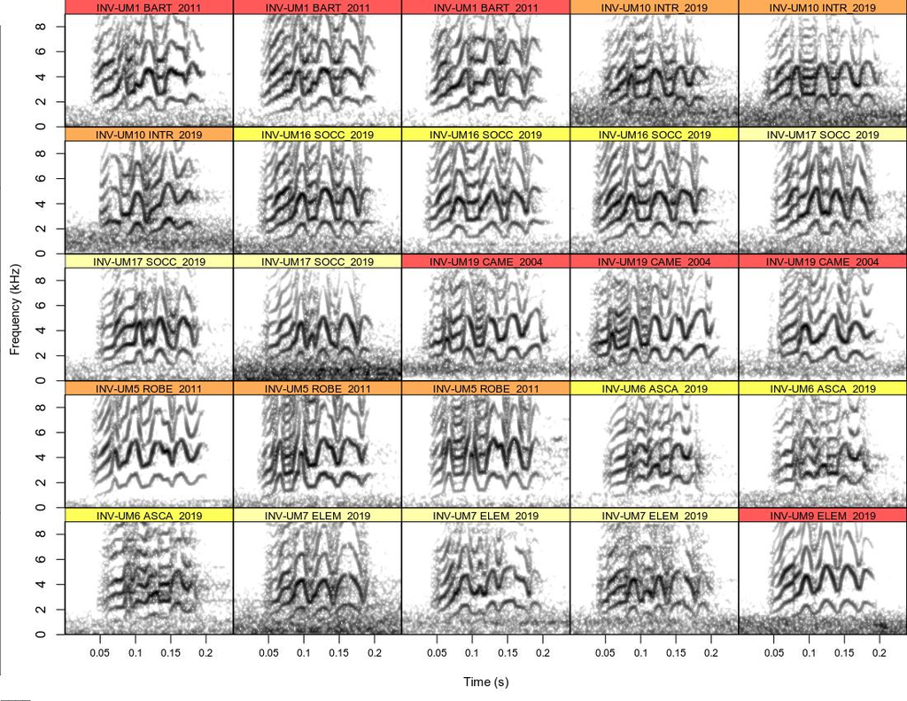

Individual scale pp 1

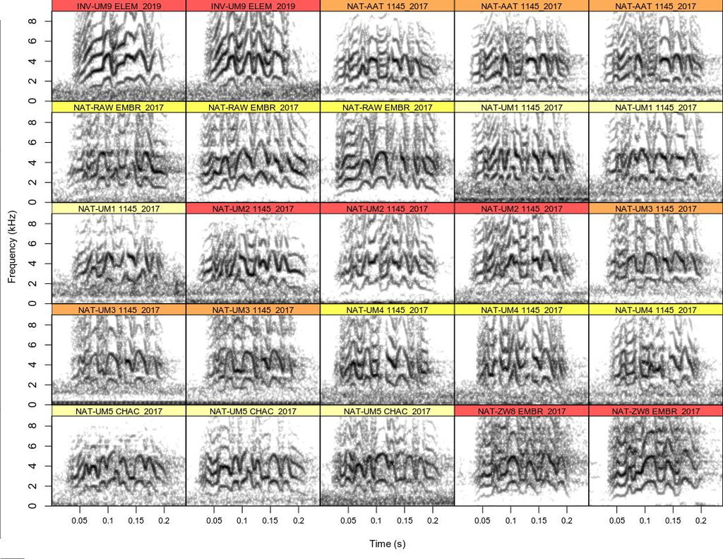

Individual scale pp 2

```r
gpath <- "/home/gsvidaurre/Desktop/GitHub_repos/identity-information-post-introduction/images"

set.seed(seed)

icalls <- nat_int_est %>%
  filter(social_scale == "Individual") %>%
  group_by(Bird_ID) %>%
  nest() %>%
  ungroup() %>%
  dplyr::mutate(
    rsamp_call = purrr::map2(data, 3, sample_n, replace = FALSE)
  ) %>%
  dplyr::select(-data) %>%
  unnest(rsamp_call) %>%
  pull(sound.files)

icalls

heat_light <- function(x){
  heat.colors(x, alpha = 0.65)
}

catalog(X = nat_int_est[grep(paste(paste("^", icalls, "$", sep = ""), collapse = "|"), nat_int_est$sound.files), ], flim = c(0, 9), nrow = 5, ncol = 5, ovlp = 90, wl = 378, orientation = "h", labels = c("Bird_ID", "site_year"), mar = 0.01, cex = 0.75, img.suffix = "indiv_scale", parallel = cores, path = path, group.tag = "Bird_ID", max.group.cols = 4, tag.pal = list(heat_light), legend = 0)

img_files <- list.files(path, pattern = "-indiv_scale.jpeg")
img_files

# Moved files to a graphics folder
file.rename(from = file.path(path, img_files), to = file.path(gpath, img_files))
```

For the site scale, I randomly sampled 5 calls per 6 randomly sampled site-years per range represented by more than 20 calls.

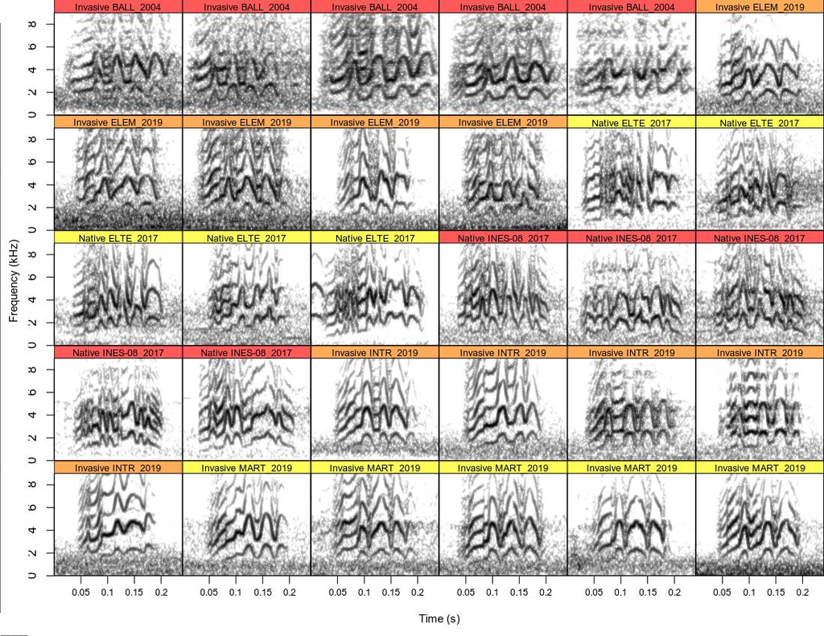

Site scale, pp 1

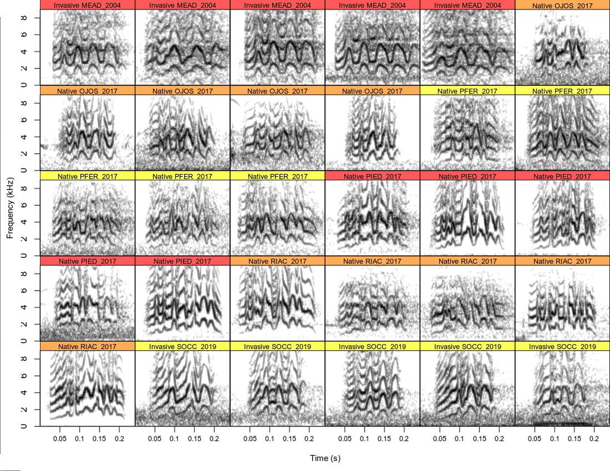

Site scale, pp 2

```r
set.seed(seed)

rsites <- nat_int_est %>%
  filter(social_scale == "Site") %>%
  group_by(range, site_year) %>%
  # Get number of calls per site-year
  dplyr::summarise(
    n_calls = length(sound.files)
  ) %>%
  # Drop sites with less than 20 calls
  filter(n_calls >= 20) %>%
  ungroup() %>%
  group_by(range) %>%
  nest() %>%
  ungroup() %>%
  dplyr::mutate(
    rsamp_sites = purrr::map2(data, 6, sample_n, replace = FALSE)
  ) %>%
  dplyr::select(-data) %>%
  unnest(rsamp_sites) %>%
  pull(site_year)

rsites

set.seed(seed)

scalls <- nat_int_est %>%
  filter(social_scale == "Site") %>%
  filter(site_year %in% rsites) %>%
  group_by(site_year) %>%
  nest() %>%
  ungroup() %>%
  dplyr::mutate(
    rsamp_call = purrr::map2(data, 5, sample_n, replace = FALSE)
  ) %>%
  dplyr::select(-data) %>%
  unnest(rsamp_call) %>%
  pull(sound.files)

scalls

# Subset the data from by these calls, and order by range
tmp_est <- nat_int_est[grep(paste(paste("^", scalls, "$", sep = ""), collapse = "|"), nat_int_est$sound.files), ]
tmp_est <- tmp_est[order(tmp_est$range), ]
# View(tmp_est)

# Ordering the extended selection table didn't change the way the spectrograms are plotted, that's ok
catalog(X = tmp_est, flim = c(0, 9), nrow = 5, ncol = 6, ovlp = 90, wl = 378, orientation = "h", labels = c("range", "site_year"), mar = 0.01, cex = 0.75, img.suffix = "site_scale", parallel = cores, path = path, group.tag = "site_year", max.group.cols = 3, tag.pal = list(heat_light), legend = 0)

img_files <- list.files(path, pattern = "-site_scale.jpeg")
img_files

# Moved files to a graphics folder
file.rename(from = file.path(path, img_files), to = file.path(gpath, img_files))
```

# Sampling maps

Sampling map of Uruguay (native range). This map was made with polygons downloaded as shapefiles from GADM version 3.6.

```r
poly_path <- "/media/gsvidaurre/MYIOPSITTA/R/Uruguay2017_MonkParakeet_CallAnalysis/Data/Site_Recordings/"

# Native range coordinates
nat_coords <- nat_int_est %>%
  dplyr::filter(range == "Native") %>%
  as_tibble() %>%
  dplyr::select(
    lat, lon, dept_state, region
  )

glimpse(nat_coords)

# Uruguay county border
URY_adm0 <- readOGR(dsn = poly_path, layer = "URY_adm0")
slotNames(URY_adm0)
proj4string(URY_adm0)

# Uruguay county borders
URY_adm1 <- readOGR(dsn = poly_path, layer = "URY_adm1")
slotNames(URY_adm1)
proj4string(URY_adm1)

# Read in Argentina and Brazil country borders
a <- readRDS(file.path(poly_path, "gadm36_ARG_0_sp.rds"))
b <- readRDS(file.path(poly_path, "gadm36_BRA_0_sp.rds"))

n <- 12
# pie(rep(1, n), col = heat.colors(n))

# make colors for water and land fill colors
wfl <- gray.colors(n, alpha = 0.5)[12]
lfl <- "white"

unique(nat_coords$dept_state)
unique(nat_coords$region)

# order departments to match the geographic transect
nat_coords$dept_state <- factor(nat_coords$dept_state, levels = c("Colonia", "San Jose", "Salto", "Canelones", "Montevideo", "Maldonado", "Rocha"))
nat_coords$region <- nat_coords$dept_state

nat_coords$region <- gsub("Canelones|Montevideo", "Canelones & Montevideo", nat_coords$region)
nat_coords$region <- factor(nat_coords$region, levels = c("Colonia", "San Jose", "Salto", "Canelones & Montevideo", "Maldonado", "Rocha"))

bufx <- 0.5
bufy <- 0.3

dev.off()

jpeg(file.path(gpath, "Sampling_map_URY.jpeg"), width = 3.5, height = 4, units = "in", res = 300)

gg_ury <- ggplot() +
  geom_polygon(aes(x = long, y = lat, group = group), color = "black",
               fill = lfl, size = 0.4, data = URY_adm0) +
  geom_polygon(aes(x = long, y = lat, group = group), color = "black",
               fill = lfl, size = 0.4, data = a) +
  geom_polygon(aes(x = long, y = lat, group = group), color = "black",
               fill = lfl, size = 0.4, data = b) +
  geom_polygon(aes(x = long, y = lat, group = group), color = "black",
               fill = lfl, size = 0.4, data = URY_adm1) +
  geom_point(data = nat_coords, aes(x = lon, y = lat), fill = scales::alpha("navy", 0.1), color = scales::alpha("navy", 0.5), shape = 21, size = 3) +
  guides(color = "none", shape = "none", size = "none", fill = "none") +
  xlab("") + ylab("") +
  theme(
    panel.background = element_rect(fill = wfl),
    panel.border = element_rect(fill = NA, color = "black", size = 1),
    plot.background = element_rect(fill = lfl),
    plot.title = element_text(size = 25, hjust = 0.5),
    panel.grid.major = element_line(size = 1, colour = wfl),
    panel.grid.minor = element_line(size = 0.75, colour = wfl),
    axis.line = element_line(size = 0.25, colour = "black"),
    axis.text = element_text(size = 11)
  ) +
  coord_cartesian(xlim = c(min(nat_coords$lon) - bufx, max(nat_coords$lon) + bufx), y = c(min(nat_coords$lat) - bufy, max(nat_coords$lat) + bufy*3))

# gg_ury

gg_ury <- gg_ury +
  scalebar(x.min = -56.5, x.max = -54.5, y.min = -35.2, y.max = -34.8, dist = 50, model = "WGS84", height = 0.25, st.size = 3, st.dist = 0.3, transform = TRUE, dist_unit = "km", border.size = 0.5)

buf <- 0.1
symbol <- 1
symbol <- sprintf("%02.f", symbol)
symbol <- readPNG(paste0(system.file("symbols", package = "ggsn"),
                         "/", symbol, ".png"))
symbol <- rasterGrob(symbol, interpolate = TRUE)
gg_ury <- gg_ury + annotation_custom(grob = symbol, xmin = -53.6, xmax = -53.1,
                                       ymin = -35.2, ymax = -34.5)

gg_ury

dev.off()
```

Sampling map of U.S. (introduced range). Get Canada and Mexico too.

```r
states <- map_data("state")
str(states)

canada <- map_data("world") %>%
  dplyr::filter(region == "Canada")
str(canada)

mexico <- map_data("world") %>%
  dplyr::filter(region == "Mexico")
str(mexico)

# Introduced range coordinates
int_coords <- nat_int_est %>%
  dplyr::filter(range == "Introduced") %>%
  as_tibble() %>%
  dplyr::select(
    lat, lon, dept_state, region
  )

glimpse(int_coords)

n <- 12

# make colors for water and land fill colors
wfl <- gray.colors(n, alpha = 0.5)[12]
lfl <- "white"

unique(int_coords$dept_state)
unique(int_coords$region)

bufx <- 0.5
bufy <- 0.3

jpeg(file.path(gpath, "Sampling_map_USA.jpeg"), width = 4.5, height = 4, units = "in", res = 300)

gg_usa <- ggplot() +
  geom_polygon(aes(x = long, y = lat, group = group), color = "black",
               fill = lfl, size = 0.4, data = states) +
  geom_polygon(aes(x = long, y = lat, group = group), color = "black",
               fill = lfl, size = 0.4, data = canada) +
  geom_polygon(aes(x = long, y = lat, group = group), color = "black",
               fill = lfl, size = 0.4, data = mexico) +
  geom_point(data = int_coords, aes(x = lon, y = lat), fill = scales::alpha("gold", 0.1), color = scales::alpha("gold", 0.5), shape = 21, size = 3) +
  guides(color = "none", shape = "none", size = "none", fill = "none") +
  xlab("") + ylab("") +
  theme(
    panel.background = element_rect(fill = wfl),
    panel.border = element_rect(fill = NA, color = "black", size = 1),
    plot.background = element_rect(fill = lfl),
    plot.title = element_text(size = 25, hjust = 0.5),
    panel.grid.major = element_line(size = 1, colour = wfl),
    panel.grid.minor = element_line(size = 0.75, colour = wfl),
    axis.line = element_line(size = 0.25, colour = "black"),
    axis.text = element_text(size = 11)
  ) +
  coord_cartesian(xlim = c(-118, -70), y = c(26, 49))

# gg_usa

gg_usa <- gg_usa +
    scalebar(x.min = -96, x.max = -86, y.min = 27, y.max = 30, dist = 500, model = "WGS84", height = 0.15, st.size = 3, st.dist = 0.25, transform = TRUE, dist_unit = "km", border.size = 0.5)

# gg_usa

buf <- 0.1
symbol <- 1
symbol <- sprintf("%02.f", symbol)
symbol <- readPNG(paste0(system.file("symbols", package = "ggsn"),
                         "/", symbol, ".png"))
symbol <- rasterGrob(symbol, interpolate = TRUE)
gg_usa <- gg_usa + annotation_custom(grob = symbol, xmin = -75, xmax = -70,
                                       ymin = 28, ymax = 31)

gg_usa

dev.off()
```

# References

```
1. Smith-Vidaurre, G., Araya-Salas, M., and T.F. Wright. 2020. Individual signatures outweigh social group identity in contact calls of a communally nesting parrot. Behavioral Ecology 31(2), 448-458. https://doi.org/10.1093/beheco/arz202

2. Buhrman-Deever, S.C., Rappaport, A.R. and J.W. Bradbury. 2007. Geographic variation in contact calls of feral North American populations of the monk parakeet. The Condor 109(2), 389-398. https://doi.org/10.1093/condor/109.2.389

3. Araya‐Salas, M., G. Smith‐Vidaurre. 2017. warbleR: An R package to streamline analysis of animal acoustic signals. Methods in Ecology and Evolution 8(2), 184-191. https://doi.org/10.1111/2041-210X.12624

4. Smith-Vidaurre, G., Perez-Marrufo, V., & Wright, T. F. 2021. Individual vocal signatures show reduced complexity following invasion. Animal Behavior, 179, 15–39. https://doi.org/10.1016/j.anbehav.2021.06.020
```